# Project: Investigate tmdbmovie_data

### Research Question 14 Which director made the highest profit on all the movies directed by them

Finding the director that made the highest profit. Meaning, if this director is hired to direct, the probability of movie's success at box office is more.

```python
#To find that which director made the highest profit for all the movies he/she directed?
director_list.idxmax()
```

```
'Steven Spielberg'
```

### Research Question 15 Number of movies directed by the directors whose profit is greater than average profit

Making a note on the count of the movies made by the directors from the above list, shows that these directots are experienced, that know about the components what have worked in the movie. There is something called directorial and cinematic excellence- the art of which they are well accustomed with. This may be one of the factors that can be taken into consideration- the number of movies(the highly grossed ones, greater than the average profit margin) made by the directors and we can count on their expertise.

```python
#.Finding the number of directors whose delivered maximum number of movies whose profitability_count exceeds the avearge profit earned
director_count = moviegreaterthanavgpcount.groupby('director')['id'].count()
director_count
```

```
director
Adam McKay                                   3
Adam Shankman                                2
Adrian Lyne                                  3
Alan J. Pakula                               1
Alan Parker                                  1
Alan Taylor                                  2
Alastair Fothergill|Mark Linfield            1
Albert Hughes|Allen Hughes                   1
Alejandro Agresti                            1
Alejandro AmenÃ¡bar                          1
Alejandro GonzÃ¡lez IÃ±Ã¡rritu               3
Alex Proyas                                  3
Alexander Payne                              3
Alexander Witt                               1
Alfonso CuarÃ³n                              2
Alister Grierson                             1
Amy Heckerling                               1
Andrew Adamson                               2
Andrew Adamson|Kelly Asbury|Conrad Vernon    1
Andrew Adamson|Vicky Jenson                  1
Andrew Davis                                 2
Andrew Douglas                               1
Andrew Niccol                                1
Andrew Stanton                               1
Andrew Stanton|Lee Unkrich                   1
Andy Fickman                                 3
Andy Muschietti                              1
Andy Tennant                                 3
Ang Lee                                      4
Angelina Jolie                               1
                                            ..
Tim Hill                                     2
Tim Johnson                                  1
Tim Johnson|Karey Kirkpatrick                1
Tim Story                                    4
Timur Bekmambetov                            1
Tobe Hooper                                  1
Tod Williams                                 1
Todd Phillips                                6
```

[output cut: 8 more lines]

```
Tony Scott                                   6
Walter Hill                                  2
Wayne Wang                                   1
Wes Anderson                                 1
Wes Ball                                     2
Wes Craven                                   3
Will Gluck                                   1
William Brent Bell                           1
William Friedkin                             1
Wolfgang Petersen                            4
Wolfgang Reitherman                          1
Woody Allen                                  3
Xavier Gens                                  1
Zack Snyder                                  3
Name: id, Length: 539, dtype: int64
```

### Research Question 16 Director who directed the movie that brought the maximum number of movies whose profit was greater than average profit

```python
#To find which director made the movies that had profit greater than the average profit margin?
director_count.idxmax()
```

```
'Steven Spielberg'
```

### Research Question 17 Release_Year Vs Profitability_count.

Understanding what year brought the highest profit. Observing the fluctuating trend in the profit earned based on year of release, understanding what year worked the best for the movies.

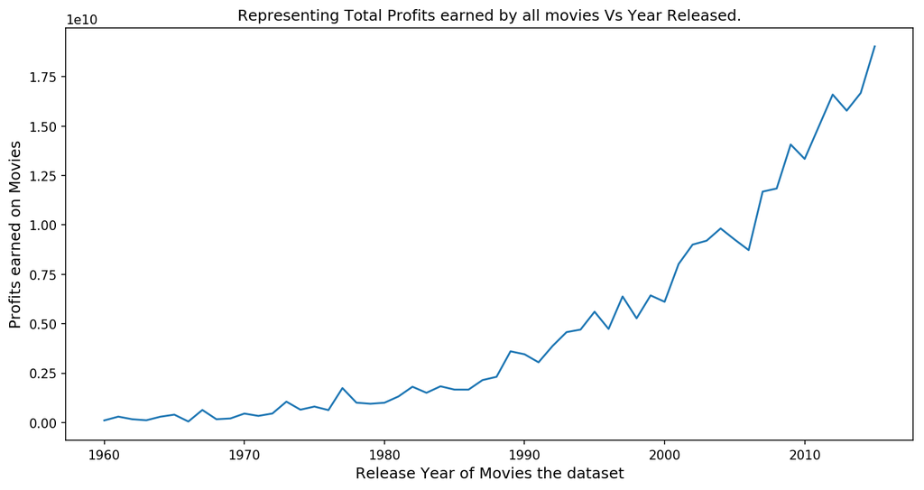

```python
#. Release_Year Vs Profitability_Count
year_list = tmdbmovie_data.groupby('release_year')['profitability_count'].sum()

#figure size(width, height)
plt.figure(figsize=(12,6), dpi = 150)

#on x-axis
plt.xlabel('Release Year of Movies the dataset', fontsize = 12)
#on y-axis
plt.ylabel('Profits earned on Movies', fontsize = 12)
#title of the line plot
plt.title('Representing Total Profits earned by all movies Vs Year Released.')

#plotting the graph
plt.plot(year_list)

#displaying the line plot
plt.show()
```

### Research Question 18 Which Year brought the highest profit?

```python
#To find that which year made the highest profit?
year_list.idxmax()
```

```
2015
```

### Research Question 19 Breakdown of year_list

```python
#.
year_list.describe()
```

```
count    5.600000e+01
mean     4.850735e+09
std      5.294931e+09
min      5.246869e+07
25%      6.470202e+08
50%      2.230812e+09
75%      8.198109e+09
max      1.903215e+10
Name: profitability_count, dtype: float64
```

```python
df_new = df_imdb.groupby('release_year').mean()
```

### Research Question 20 Most frequent cast for movies

```python
### Finding the most frequent cast for movies
def data_count(column_passed):

    data_count = tmdbmovie_data[column_passed].str.cat(sep = '|')

    #giving pandas series and storing the values separately
    data_count = pd.Series(data_count.split('|'))

    #arranging in descending order
    count_value = data_count.value_counts(ascending = False)

    return count_value

#variable to store the retured value
count_value = data_count('cast')
#printing values
count_value
```

```
Robert De Niro           52
Bruce Willis             46
Samuel L. Jackson        44
Nicolas Cage             43
Matt Damon               36
Johnny Depp              35
Sylvester Stallone       34
Tom Hanks                34
Morgan Freeman           34
Harrison Ford            34
Brad Pitt                34
Tom Cruise               33
Denzel Washington        32
Eddie Murphy             32
Liam Neeson              31
Owen Wilson              30
Julianne Moore           30
Willem Dafoe             29
Meryl Streep             29
Gene Hackman             29
Mark Wahlberg            29
Arnold Schwarzenegger    29
Robin Williams           29
Jim Carrey               28
Ewan McGregor            28
Ben Affleck              28
Cameron Diaz             28
Dennis Quaid             28
Keanu Reeves             28
Antonio Banderas         27
                         ..
Tory Mussett              1
Tina Turner               1
Michael Des Barres        1
Bill Thornbury            1
Andrea Martin             1
Hannibal Buress           1
Derrick Branche           1
Jennifer O'Neill          1
Zachary Gray              1
Constance Marie           1
Barry Watson              1
Cyndi Mayo Davis          1
Daniel Studi              1
Michael Irvin             1
Terence Donovan           1
Friederike Kempter        1
Vincent Hammond           1
Govinda                   1
Diane Ladd                1
Nathalie Kelley           1
Bailey Spry               1
Kelly Paterniti           1
Geeta Masi                1
Venetta Fields            1
Pell James                1
Bradley Gregg             1
Peter Friedman            1
Casey Stevens             1
Roger E. Mosley           1
PJ DeBoy                  1
Length: 6839, dtype: int64
```

### Research Question 21 Finding the cast with the maximum appearence

```python
count_value.idxmax()
```

```
'Robert De Niro'
```

## Conclusions

1. There are chances that including and getting the movies directed by directors who directed movies that brought in profit greater than average profit margins, ensures that getting movies by these directors may bring in a greater profit return for the movie.
2. The most frequent cast in the movie, throws an insight to the fact their movie sells out well at the box office. So, signing them up may bring in more business. Going by the current stats, Robert Be Noir is the most popular/frequent actor.
3. The year stats shows what year worked best for the movies from the profit return objective. It was in the year 2015, that the highest profit was observed.
4. All in one, it's not the year but the focus must be on the director and the cast to ensure that the movie does good at the box office. Bringing right people on board, works like magic for the movie.

```python
from subprocess import call
call(['python', '-m', 'nbconvert', 'Investigate_a_Dataset.ipynb'])
```

```
0
```